# Assignment 1 - Reproducible Research

Ignacio GonzÃ¡lvez

Thursday, October 15, 2015

## Loading and preprocessing the data

```r
temporal <- tempfile()
url <- "https://d396qusza40orc.cloudfront.net/repdata/data/activity.zip"
download.file(url, temporal, method="libcurl")
datos <- read.csv(unz(temporal, "activity.csv"), header=TRUE, sep=",")
datos_original <- read.csv(unz(temporal, "activity.csv"), header=TRUE, sep=",")
unlink(temporal)
# summary(datos)
```

### 1. Calculate the total number of steps taken per day

```r
steps.date <- aggregate(steps ~ date, data = datos, sum)
```

### 2. If you do not understand the difference between a histogram and a barplot, research the difference between them. Make a histogram of the total number of steps taken each day

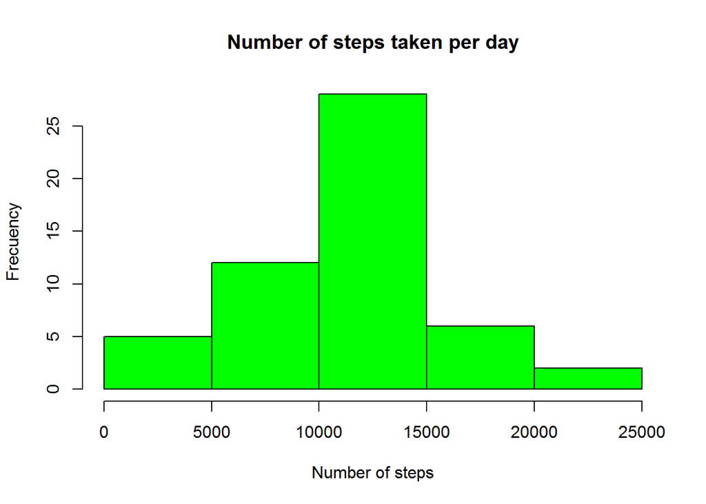

```r
hist(steps.date$steps, col="green", main="Number of steps taken per day", xlab="Number of steps", ylab="Frecuency")
```

### 3. Calculate and report the mean and median total number of steps taken per day

```r
Mediadepasosdiaria <- mean(steps.date$steps)
Mediadepasosdiaria
```

```
## [1] 10766.19
```

```r
Medianadepasosdiaria <- median(steps.date$steps)
Medianadepasosdiaria
```

```
## [1] 10765
```

## What is the average daily activity pattern?

### 1. Make a time series plot (i.e. type = “l”) of the 5-minute interval (x-axis) and the average number of steps taken, averaged across all days (y-axis)

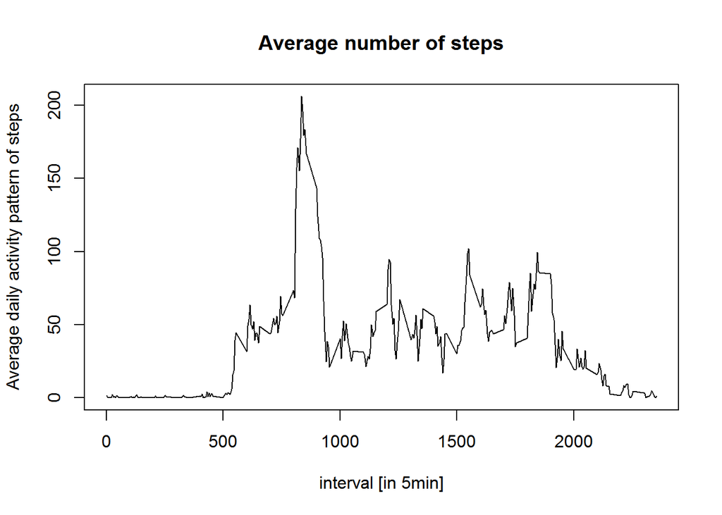

```r
steps.intervalo <- aggregate(steps ~ interval, data = datos, mean)
plot(steps.intervalo, type = "l", xlab="interval [in 5min]", ylab="Average daily activity pattern of steps",  main="Average number of steps")
```

### 2. Which 5-minute interval, on average across all the days in the dataset, contains the maximum number of steps?

```r
Maximoenintervalo <-steps.intervalo$interval[which.max(steps.intervalo$steps)]
Maximoenintervalo
```

```
## [1] 835
```

## Imputing missing values

Note that there are a number of days/intervals where there are missing values (coded as NA). The presence of missing days may introduce bias into some calculations or summaries of the data.

### 1. Calculate and report the total number of missing values in the dataset (i.e. the total number of rows with NAs)

```r
steps.NA <- is.na(datos$steps)
sum(steps.NA)
```

```
## [1] 2304
```

### 2. Devise a strategy for filling in all of the missing values in the dataset. The strategy does not need to be sophisticated. For example, you could use the mean/median for that day, or the mean for that 5-minute interval, etc.

[output not shown]

```r
datos_new <- merge(datos, steps.intervalo, by = "interval", suffixes = c(".media", ".y"))
datos_new$steps[steps.NA] <- Mediadepasosdiaria
datos_new <- datos[, c(1:3)]
```

# Perform the imputation

```r
steps.sum_intervalo <- aggregate(steps ~ interval, data = datos, sum)
for (i in 1:nrow(datos)){
  if (is.na(datos_new$steps[i])){
    intervalo_valores <- datos$interval[i]
    row_id <- which(steps.sum_intervalo$interval == intervalo_valores)
    steps_val <- steps.sum_intervalo$steps[row_id]
    datos_new$steps[i] <- steps_val
  }
}


#for (i in 1:nrow(datos)){
#  if (is.na(datos$steps[i])){
#    intervalo_valores <- datos$interval[i]
#    row_id <- which(steps.intervalo$interval == intervalo_valores)
#    steps_val <- steps.intervalo$steps[row_id]
#    datos$steps[i] <- steps_val
#  }
#}
```

### 3. Create a new dataset that is equal to the original dataset but with the missing data filled in.

```r
# table_interval_steps <- aggregate(steps ~ interval, datos, mean)
newdatasetfilled <- datos
newdatasetfilled$steps[steps.NA] <- Mediadepasosdiaria
```

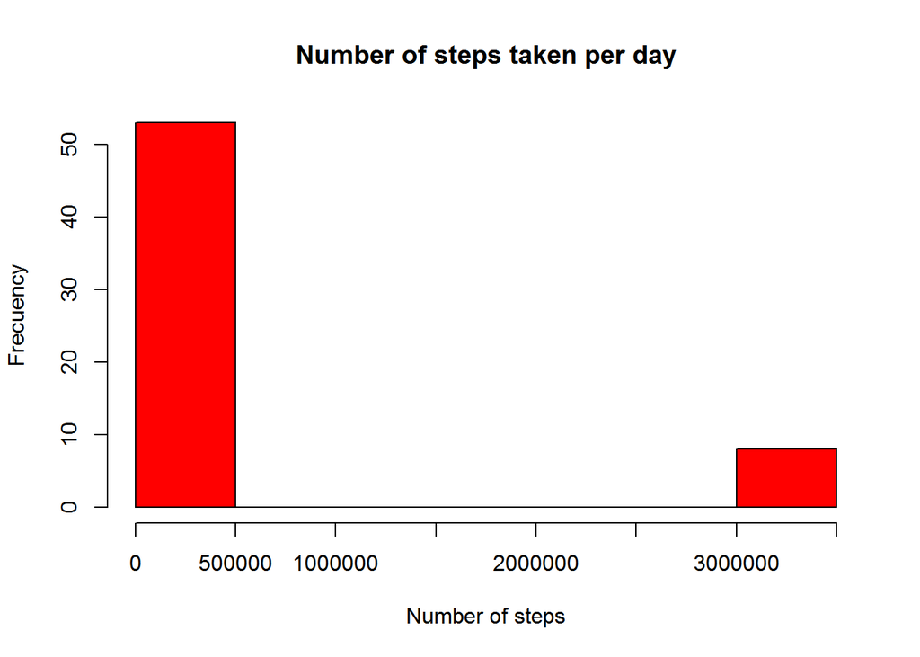

```r
table_diary_steps <- aggregate(steps ~ date, newdatasetfilled, sum)
tabla_mean_day <- aggregate(steps ~ date, newdatasetfilled, mean)
tabla_median_day <- aggregate(steps ~ date, newdatasetfilled, median)

#vector_datos <- c(datos$steps)
vector_datos <- c(datos_new$steps)
# vector_datos <- c(table_interval_steps$steps)
#print("Generating the plot1.png file .....")
#png(file="./plot1.png", width = 480, height = 480, units = "px") # open file png
hist(table_diary_steps$steps, col="red", main="Number of steps taken per day", xlab="Number of steps", ylab="Frecuency")
```

```r
#dev.off() ## close de png file
```